# Athletes_project

```python
import pandas as pd
import os
import glob
import matplotlib.pyplot as plt
import seaborn as sns

from matplotlib import rcParams
from functools import partial
from scipy.stats import shapiro
from scipy.stats import ttest_ind
from scipy.stats import chisquare
```

## 1. Read files to one table

```python
path = "/home/natalya/Stat_BI_2022/athlete_events"
extension = "csv"
```

```python
def read_results(path, extension):
    files = glob.glob(os.path.join(path, "*." + extension))
    if extension == "csv":
        pd_function = partial(pd.read_csv, sep = ",")
    elif extension == "tsv":
        pd_function = partial(pd.read_csv, sep = "\t")
    elif extension == "xslx":
        pd_function = pd.read_excel
    dfs = []
    for f in files:
        df = pd_function(f)
        dfs.append(df)
    athlete_events = pd.concat(dfs)
    return athlete_events
```

```python
athlete_events = read_results(path, extension)
```

## 2. Check the data

```python
athlete_events
```

|  | ID | Name | Sex | Age | Height | Weight | Team | NOC | Games | Year | Season | City | Sport | Event | Medal |
| --- | --- | --- | --- | --- | --- | --- | --- | --- | --- | --- | --- | --- | --- | --- | --- |
| 0 | 113716 | Pietro Speciale | M | 43.0 | NaN | NaN | Italy | ITA | 1920 Summer | 1920.0 | Summer | Antwerpen | Fencing | Fencing Men's Foil, Individual | NaN |
| 1 | 113716 | Pietro Speciale | M | 43.0 | NaN | NaN | Italy | ITA | 1920 Summer | 1920.0 | Summer | Antwerpen | Fencing | Fencing Men's Foil, Team | Gold |
| 2 | 113717 | Robert Speck | M | 27.0 | NaN | NaN | Romania | ROU | 1936 Summer | 1936.0 | Summer | Berlin | Handball | Handball Men's Handball | NaN |
| 3 | 113718 | Walter Edward "Walt" Speck | M | 35.0 | NaN | NaN | United States | USA | 1932 Summer | 1932.0 | Summer | Los Angeles | Art Competitions | Art Competitions Mixed Painting, Unknown Event | NaN |
| 4 | 113718 | Walter Edward "Walt" Speck | M | 35.0 | NaN | NaN | United States | USA | 1932 Summer | 1932.0 | Summer | Los Angeles | Art Competitions | Art Competitions Mixed Painting, Unknown Event | NaN |
| ... | ... | ... | ... | ... | ... | ... | ... | ... | ... | ... | ... | ... | ... | ... | ... |
| 22831 | 12004 | Peter Grant Blackburn | M | 28.0 | 179.0 | 78.0 | Australia | AUS | 1996 Summer | 1996.0 | Summer | Atlanta | Badminton | Badminton Mixed Doubles | NaN |
| 22832 | 12004 | Peter Grant Blackburn | M | 28.0 | 179.0 | 78.0 | Australia | AUS | 1996 Summer | 1996.0 | Summer | Atlanta | Badminton | Badminton Men's Doubles | NaN |
| 22833 | 12004 | Peter Grant Blackburn | M | 32.0 | 179.0 | 78.0 | Australia | AUS | 2000 Summer | 2000.0 | Summer | Sydney | Badminton | Badminton Mixed Doubles | NaN |
| 22834 | 12004 | Peter Grant Blackburn | M | 32.0 | 179.0 | 78.0 | Australia | AUS | 2000 Summer | 2000.0 | Summer | Sydney | Badminton | Badminton Men's Doubles | NaN |
| 22835 | 12005 | Andrea Melissa Blackett | F | 24.0 | 167.0 | 59.0 | Barbados | BAR | 2000 Su | NaN | NaN | NaN | NaN | NaN | NaN |

271115 rows × 15 columns

```python
sum(athlete_events.duplicated())
```

```
1385
```

There are duplicated rows. Let's delete them - they can distort our results.

```python
athlete_events = athlete_events.drop_duplicates()
```

Let's check if there is any NAs.

```python
athlete_events.isna().sum()
```

```
ID             0
Name           1
Sex            2
Age         9317
Height     58815
Weight     61528
Team           3
NOC            4
Games          5
Year           7
Season         7
City           7
Sport          7
Event          8
Medal     229959
dtype: int64
```

Yes, there are some. We could leava them as it is (because usually various function can deal with NA). Numeric variables we could replace with mean value (but it's strange to replace object variables with smth). Sometimes NAs are replaced witht zeros (but here it would be wrong).

In this case I'd prefer to drop row with NAs, because we have plenty of data, which is enough for our exploratory analysis. Of course, we shouldn't drop NAs in column 'Medal'.

```python
athlete_events.columns
```

```
Index(['ID', 'Name', 'Sex', 'Age', 'Height', 'Weight', 'Team', 'NOC', 'Games',
       'Year', 'Season', 'City', 'Sport', 'Event', 'Medal'],
      dtype='object')
```

```python
athlete_events = athlete_events.dropna(subset=['Name', 'Sex', 'Age', 'Height', 'Weight', 'Team', 'NOC', 'Games',
       'Year', 'Season', 'City', 'Sport', 'Event'])
```

```python
athlete_events.shape[0]
```

```
206146
```

```python
athlete_events.isna().sum()
```

```
ID             0
Name           0
Sex            0
Age            0
Height         0
Weight         0
Team           0
NOC            0
Games          0
Year           0
Season         0
City           0
Sport          0
Event          0
Medal     175965
dtype: int64
```

Let's reset row indecies.

```python
athlete_events.index = list(range(athlete_events.shape[0]))
```

```python
athlete_events.tail()
```

|  | ID | Name | Sex | Age | Height | Weight | Team | NOC | Games | Year | Season | City | Sport | Event | Medal |
| --- | --- | --- | --- | --- | --- | --- | --- | --- | --- | --- | --- | --- | --- | --- | --- |
| 206141 | 12003 | Michael James Blackburn | M | 34.0 | 178.0 | 78.0 | Australia | AUS | 2004 Summer | 2004.0 | Summer | Athina | Sailing | Sailing Mixed One Person Dinghy | NaN |
| 206142 | 12004 | Peter Grant Blackburn | M | 28.0 | 179.0 | 78.0 | Australia | AUS | 1996 Summer | 1996.0 | Summer | Atlanta | Badminton | Badminton Mixed Doubles | NaN |
| 206143 | 12004 | Peter Grant Blackburn | M | 28.0 | 179.0 | 78.0 | Australia | AUS | 1996 Summer | 1996.0 | Summer | Atlanta | Badminton | Badminton Men's Doubles | NaN |
| 206144 | 12004 | Peter Grant Blackburn | M | 32.0 | 179.0 | 78.0 | Australia | AUS | 2000 Summer | 2000.0 | Summer | Sydney | Badminton | Badminton Mixed Doubles | NaN |
| 206145 | 12004 | Peter Grant Blackburn | M | 32.0 | 179.0 | 78.0 | Australia | AUS | 2000 Summer | 2000.0 | Summer | Sydney | Badminton | Badminton Men's Doubles | NaN |

Let's check data types.

```python
athlete_events.dtypes
```

```
ID          int64
Name       object
Sex        object
Age       float64
Height    float64
Weight    float64
Team       object
NOC        object
Games      object
Year      float64
Season     object
City       object
Sport      object
Event      object
Medal      object
dtype: object
```

```python
athlete_events['Year'] = athlete_events['Year'].astype('int64')
```

```python
athlete_events.dtypes
```

```
ID          int64
Name       object
Sex        object
Age       float64
Height    float64
Weight    float64
Team       object
NOC        object
Games      object
Year        int64
Season     object
City       object
Sport      object
Event      object
Medal      object
dtype: object
```

And some descriptive statistics

```python
athlete_events.describe()
```

|  | ID | Age | Height | Weight | Year |
| --- | --- | --- | --- | --- | --- |
| count | 206146.000000 | 206146.000000 | 206146.000000 | 206146.000000 | 206146.000000 |
| mean | 68615.858503 | 25.054738 | 175.372993 | 70.688687 | 1989.678403 |
| std | 38996.979918 | 5.481717 | 10.552121 | 14.340838 | 20.125790 |
| min | 1.000000 | 11.000000 | 127.000000 | 25.000000 | 1896.000000 |
| 25% | 35189.000000 | 21.000000 | 168.000000 | 60.000000 | 1976.000000 |
| 50% | 68629.000000 | 24.000000 | 175.000000 | 70.000000 | 1992.000000 |
| 75% | 102312.000000 | 28.000000 | 183.000000 | 79.000000 | 2006.000000 |
| max | 135571.000000 | 71.000000 | 340.000000 | 214.000000 | 2016.000000 |

It's impossible to be 340 cm high...

```python
athlete_events.query("Height == 340")
```

|  | ID | Name | Sex | Age | Height | Weight | Team | NOC | Games | Year | Season | City | Sport | Event | Medal |
| --- | --- | --- | --- | --- | --- | --- | --- | --- | --- | --- | --- | --- | --- | --- | --- |
| 104365 | 23549 | Kirsty Leigh Coventry (-Seward) | F | 28.0 | 340.0 | 64.0 | Zimbabwe | ZIM | 2012 Summer | 2012 | Summer | London | Swimming | Swimming Women's 200 metres Individual Medley | NaN |

```python
athlete_events.query("ID == 23549")
```

|  | ID | Name | Sex | Age | Height | Weight | Team | NOC | Games | Year | Season | City | Sport | Event | Medal |
| --- | --- | --- | --- | --- | --- | --- | --- | --- | --- | --- | --- | --- | --- | --- | --- |
| 104352 | 23549 | Kirsty Leigh Coventry (-Seward) | F | 16.0 | 176.0 | 64.0 | Zimbabwe | ZIM | 2000 Summer | 2000 | Summer | Sydney | Swimming | Swimming Women's 50 metres Freestyle | NaN |
| 104353 | 23549 | Kirsty Leigh Coventry (-Seward) | F | 16.0 | 176.0 | 64.0 | Zimbabwe | ZIM | 2000 Summer | 2000 | Summer | Sydney | Swimming | Swimming Women's 100 metres Freestyle | NaN |
| 104354 | 23549 | Kirsty Leigh Coventry (-Seward) | F | 16.0 | 176.0 | 64.0 | Zimbabwe | ZIM | 2000 Summer | 2000 | Summer | Sydney | Swimming | Swimming Women's 100 metres Backstroke | NaN |
| 104355 | 23549 | Kirsty Leigh Coventry (-Seward) | F | 16.0 | 176.0 | 64.0 | Zimbabwe | ZIM | 2000 Summer | 2000 | Summer | Sydney | Swimming | Swimming Women's 200 metres Individual Medley | NaN |
| 104356 | 23549 | Kirsty Leigh Coventry (-Seward) | F | 20.0 | 176.0 | 64.0 | Zimbabwe | ZIM | 2004 Summer | 2004 | Summer | Athina | Swimming | Swimming Women's 100 metres Backstroke | Silver |
| 104357 | 23549 | Kirsty Leigh Coventry (-Seward) | F | 20.0 | 176.0 | 64.0 | Zimbabwe | ZIM | 2004 Summer | 2004 | Summer | Athina | Swimming | Swimming Women's 200 metres Backstroke | Gold |
| 104358 | 23549 | Kirsty Leigh Coventry (-Seward) | F | 20.0 | 176.0 | 64.0 | Zimbabwe | ZIM | 2004 Summer | 2004 | Summer | Athina | Swimming | Swimming Women's 200 metres Individual Medley | Bronze |
| 104359 | 23549 | Kirsty Leigh Coventry (-Seward) | F | 24.0 | 176.0 | 64.0 | Zimbabwe | ZIM | 2008 Summer | 2008 | Summer | Beijing | Swimming | Swimming Women's 100 metres Backstroke | Silver |
| 104360 | 23549 | Kirsty Leigh Coventry (-Seward) | F | 24.0 | 176.0 | 64.0 | Zimbabwe | ZIM | 2008 Summer | 2008 | Summer | Beijing | Swimming | Swimming Women's 200 metres Backstroke | Gold |
| 104361 | 23549 | Kirsty Leigh Coventry (-Seward) | F | 24.0 | 176.0 | 64.0 | Zimbabwe | ZIM | 2008 Summer | 2008 | Summer | Beijing | Swimming | Swimming Women's 200 metres Individual Medley | Silver |
| 104362 | 23549 | Kirsty Leigh Coventry (-Seward) | F | 24.0 | 176.0 | 64.0 | Zimbabwe | ZIM | 2008 Summer | 2008 | Summer | Beijing | Swimming | Swimming Women's 400 metres Individual Medley | Silver |
| 104363 | 23549 | Kirsty Leigh Coventry (-Seward) | F | 28.0 | 176.0 | 64.0 | Zimbabwe | ZIM | 2012 Summer | 2012 | Summer | London | Swimming | Swimming Women's 100 metres Backstroke | NaN |
| 104364 | 23549 | Kirsty Leigh Coventry (-Seward) | F | 28.0 | 176.0 | 64.0 | Zimbabwe | ZIM | 2012 Summer | 2012 | Summer | London | Swimming | Swimming Women's 200 metres Backstroke | NaN |
| 104365 | 23549 | Kirsty Leigh Coventry (-Seward) | F | 28.0 | 340.0 | 64.0 | Zimbabwe | ZIM | 2012 Summer | 2012 | Summer | London | Swimming | Swimming Women's 200 metres Individual Medley | NaN |
| 104366 | 23549 | Kirsty Leigh Coventry (-Seward) | F | 32.0 | 176.0 | 64.0 | Zimbabwe | ZIM | 2016 Summer | 2016 | Summer | Rio de Janeiro | Swimming | Swimming Women's 100 metres Backstroke | NaN |
| 104367 | 23549 | Kirsty Leigh Coventry (-Seward) | F | 32.0 | 176.0 | 64.0 | Zimbabwe | ZIM | 2016 Summer | 2016 | Summer | Rio de Janeiro | Swimming | Swimming Women's 200 metres Backstroke | NaN |

Looks like she was actually 176 high.

```python
outlier_line_idx = athlete_events.query("Height == 340").index
```

```python
athlete_events.loc[outlier_line_idx, "Height"] = 176
```

```python
athlete_events["Height"].describe()
```

```
count    206146.000000
mean        175.372197
std          10.545890
min         127.000000
25%         168.000000
50%         175.000000
75%         183.000000
max         226.000000
Name: Height, dtype: float64
```

```python
athlete_events.query("Height == 226")
```

|  | ID | Name | Sex | Age | Height | Weight | Team | NOC | Games | Year | Season | City | Sport | Event | Medal |
| --- | --- | --- | --- | --- | --- | --- | --- | --- | --- | --- | --- | --- | --- | --- | --- |
| 47133 | 132627 | Yao Ming | M | 20.0 | 226.0 | 141.0 | China | CHN | 2000 Summer | 2000 | Summer | Sydney | Basketball | Basketball Men's Basketball | NaN |
| 47134 | 132627 | Yao Ming | M | 23.0 | 226.0 | 141.0 | China | CHN | 2004 Summer | 2004 | Summer | Athina | Basketball | Basketball Men's Basketball | NaN |
| 47135 | 132627 | Yao Ming | M | 27.0 | 226.0 | 141.0 | China | CHN | 2008 Summer | 2008 | Summer | Beijing | Basketball | Basketball Men's Basketball | NaN |

```python
athlete_events.query("ID == 132627")
```

|  | ID | Name | Sex | Age | Height | Weight | Team | NOC | Games | Year | Season | City | Sport | Event | Medal |
| --- | --- | --- | --- | --- | --- | --- | --- | --- | --- | --- | --- | --- | --- | --- | --- |
| 47133 | 132627 | Yao Ming | M | 20.0 | 226.0 | 141.0 | China | CHN | 2000 Summer | 2000 | Summer | Sydney | Basketball | Basketball Men's Basketball | NaN |
| 47134 | 132627 | Yao Ming | M | 23.0 | 226.0 | 141.0 | China | CHN | 2004 Summer | 2004 | Summer | Athina | Basketball | Basketball Men's Basketball | NaN |
| 47135 | 132627 | Yao Ming | M | 27.0 | 226.0 | 141.0 | China | CHN | 2008 Summer | 2008 | Summer | Beijing | Basketball | Basketball Men's Basketball | NaN |

Ok, this guy was really that tall.

```python
athlete_events[["Sex", "Season", "Medal"]].apply(pd.unique)
```

```
Sex                         [M, F, G]
Season               [Summer, Winter]
Medal     [Bronze, nan, Silver, Gold]
dtype: object
```

What is G gender?

```python
athlete_events.query("Sex == 'G'")
```

|  | ID | Name | Sex | Age | Height | Weight | Team | NOC | Games | Year | Season | City | Sport | Event | Medal |
| --- | --- | --- | --- | --- | --- | --- | --- | --- | --- | --- | --- | --- | --- | --- | --- |
| 69473 | 79609 | Pavel Mike | G | 22.0 | 182.0 | 79.0 | Czechoslovakia | TCH | 1972 Summer | 1972 | Summer | Munich | Handball | Handball Men's Handball | Silver |

Looks like he is a man.

```python
index_g = athlete_events.query("Sex == 'G'").index
```

```python
athlete_events.loc[index_g, "Sex"] = "M"
```

```python
athlete_events["Sex"].unique()
```

```
array(['M', 'F'], dtype=object)
```

## 3. Youngest sportswoman and sportsman

```python
answer = athlete_events.groupby('Sex').agg({'Age': 'min'})
answer
```

| Sex | Age |
| --- | --- |
| F | 11.0 |
| M | 12.0 |

```python
m = int(answer.loc['M'][0])
f = int(answer.loc['F'][0])
```

```python
print(f'The youngest sportswoman was {f} years old and the youngest sportsman was {m} years old.')
```

```
The youngest sportswoman was 11 years old and the youngest sportsman was 12 years old.
```

## 4. Mean and sd of Height

```python
athlete_events.groupby('Sex').agg({'Height': ['mean', 'std']})
```

| Sex | Height mean | Height std |
| --- | --- | --- |
| F | 167.861398 | 8.768026 |
| M | 178.965490 | 9.367154 |

## 5. Mean and sd of Height of female tennis players

```python
mean = athlete_events.query("Sex == 'F' & Year == 2000 & Sport == 'Tennis'")["Height"].mean()
round(mean, 1)
```

```
171.8
```

```python
std = athlete_events.query("Sex == 'F' & Year == 2000 & Sport == 'Tennis'")["Height"].std()
round(std, 1)
```

```
6.5
```

## 6. Heaviest athlet in 2006

```python
idx_line = athlete_events.query("Year == 2006")["Weight"].idxmax()
athlete_events.loc[idx_line, "Sport"]
```

```
'Skeleton'
```

## 7. Gold medals women from 1980 to 2010

```python
athlete_events.query("Sex == 'F' & 1980 <= Year <= 2010 & Medal == 'Gold'").shape[0]
```

```
2167
```

## 8. John Aalberg

```python
athlete_events.query("Name == 'John Aalberg'")["Year"].nunique()
```

```
2
```

## 9. Age groups in 2008

```python
subset_2008 = athlete_events.query("Year == 2008")
```

```python
age_points = [15, 25, 35, 45, 55]
```

```python
for i in range(len(age_points) - 2):
    l_b = age_points[i]
    r_b = age_points[i+1]
    number = subset_2008.query("@l_b <= Age < @r_b")["ID"].nunique()
    print(f"Nummber of sportsmen and sportswomen aged from {l_b} up to {r_b} is {number}.")
l_b = age_points[-2]
r_b = age_points[-1]
number = subset_2008.query("@l_b <= Age < @r_b")["ID"].nunique()
print(f"Nummber of sportsmen and sportswomen aged from {l_b} to {r_b} (including) is {number}.")
```

```
Nummber of sportsmen and sportswomen aged from 15 up to 25 is 4682.
Nummber of sportsmen and sportswomen aged from 25 up to 35 is 5327.
Nummber of sportsmen and sportswomen aged from 35 up to 45 is 619.
Nummber of sportsmen and sportswomen aged from 45 to 55 (including) is 75.
```

There were a lot of people aged 25-35. There was few people aged 45-55.

## 10. Number of sports in 1994 and 2002

```python
sports_2002 = athlete_events.query("Year == 2002")["Sport"].nunique()
sports_1994 = athlete_events.query("Year == 1994")["Sport"].nunique()
difference = sports_2002 - sports_1994
print(f"""Nummber of various sports in 2002 was {sports_2002} and in 1994 was {sports_1994}.
In 2002 there were {difference} sports more.""")
```

```
Nummber of various sports in 2002 was 15 and in 1994 was 12.
In 2002 there were 3 sports more.
```

## 11. TOP 3 Teams

```python
subset_medals = athlete_events.dropna()
```

```python
subset_medals.groupby(['Season', 'Medal'])['NOC'].agg(pd.Series.mode)
```

```
Season  Medal
Summer  Bronze    USA
        Gold      USA
        Silver    USA
Winter  Bronze    FIN
        Gold      CAN
        Silver    USA
Name: NOC, dtype: object
```

## 12. Standartization

```python
height_mu = athlete_events["Height"].mean()
height_std = athlete_events["Height"].std()
```

```python
athlete_events["Height_z_scores"] = (athlete_events["Height"] - height_mu) / height_std
```

```python
athlete_events.head()
```

|  | ID | Name | Sex | Age | Height | Weight | Team | NOC | Games | Year | Season | City | Sport | Event | Medal | Height_z_scores |
| --- | --- | --- | --- | --- | --- | --- | --- | --- | --- | --- | --- | --- | --- | --- | --- | --- |
| 0 | 113720 | Roscko Shane Specman | M | 27.0 | 174.0 | 81.0 | South Africa | RSA | 2016 Summer | 2016 | Summer | Rio de Janeiro | Rugby Sevens | Rugby Sevens Men's Rugby Sevens | Bronze | -0.130117 |
| 1 | 113721 | Laura Spector | F | 22.0 | 152.0 | 50.0 | United States | USA | 2010 Winter | 2010 | Winter | Vancouver | Biathlon | Biathlon Women's 7.5 kilometres Sprint | NaN | -2.216238 |
| 2 | 113721 | Laura Spector | F | 22.0 | 152.0 | 50.0 | United States | USA | 2010 Winter | 2010 | Winter | Vancouver | Biathlon | Biathlon Women's 15 kilometres | NaN | -2.216238 |
| 3 | 113721 | Laura Spector | F | 22.0 | 152.0 | 50.0 | United States | USA | 2010 Winter | 2010 | Winter | Vancouver | Biathlon | Biathlon Women's 4 x 6 kilometres Relay | NaN | -2.216238 |
| 4 | 113722 | Charles "Charlie" Spedding | M | 32.0 | 173.0 | 63.0 | Great Britain | GBR | 1984 Summer | 1984 | Summer | Los Angeles | Athletics | Athletics Men's Marathon | Bronze | -0.224940 |

## 13. min-max scale

Min-max normalization gets all the scaled data in the range (0, 1)

```python
height_min = athlete_events["Height"].min()
height_max = athlete_events["Height"].max()
```

```python
height_max, height_min
```

```
(226.0, 127.0)
```

```python
athlete_events["Height_min_max_scaled"] = (athlete_events["Height"] - height_min)/(height_max - height_min)
```

```python
athlete_events.head()
```

|  | ID | Name | Sex | Age | Height | Weight | Team | NOC | Games | Year | Season | City | Sport | Event | Medal | Height_z_scores | Height_min_max_scaled |
| --- | --- | --- | --- | --- | --- | --- | --- | --- | --- | --- | --- | --- | --- | --- | --- | --- | --- |
| 0 | 113720 | Roscko Shane Specman | M | 27.0 | 174.0 | 81.0 | South Africa | RSA | 2016 Summer | 2016 | Summer | Rio de Janeiro | Rugby Sevens | Rugby Sevens Men's Rugby Sevens | Bronze | -0.130117 | 0.474747 |
| 1 | 113721 | Laura Spector | F | 22.0 | 152.0 | 50.0 | United States | USA | 2010 Winter | 2010 | Winter | Vancouver | Biathlon | Biathlon Women's 7.5 kilometres Sprint | NaN | -2.216238 | 0.252525 |
| 2 | 113721 | Laura Spector | F | 22.0 | 152.0 | 50.0 | United States | USA | 2010 Winter | 2010 | Winter | Vancouver | Biathlon | Biathlon Women's 15 kilometres | NaN | -2.216238 | 0.252525 |
| 3 | 113721 | Laura Spector | F | 22.0 | 152.0 | 50.0 | United States | USA | 2010 Winter | 2010 | Winter | Vancouver | Biathlon | Biathlon Women's 4 x 6 kilometres Relay | NaN | -2.216238 | 0.252525 |
| 4 | 113722 | Charles "Charlie" Spedding | M | 32.0 | 173.0 | 63.0 | Great Britain | GBR | 1984 Summer | 1984 | Summer | Los Angeles | Athletics | Athletics Men's Marathon | Bronze | -0.224940 | 0.464646 |

## 14. Height, weight, age of men and women in winter season

```python
winter_subset = athlete_events.query("Season == 'Winter'")[['Sex', 'Age', 'Height', 'Weight']]
```

```python
winter_f_subset = winter_subset.query('Sex == "F"')
```

```python
winter_m_subset = winter_subset.query('Sex == "M"')
```

```python
winter_f_subset.var()
```

```
Age       21.610360
Height    36.302927
Weight    49.849714
dtype: float64
```

```python
winter_m_subset.var()
```

```
Age        20.918041
Height     43.061905
Weight    106.165993
dtype: float64
```

The number of observations is quite big, so we ca use T-test. We can use independant T-test because our two samples are independant.

```python
ttest_ind(winter_f_subset['Age'], winter_m_subset['Age'])
```

```
Ttest_indResult(statistic=-25.18013621336959, pvalue=8.284580329528672e-139)
```

```python
rcParams['figure.figsize'] = 11.7,8.27
rcParams['font.size'] =  22
```

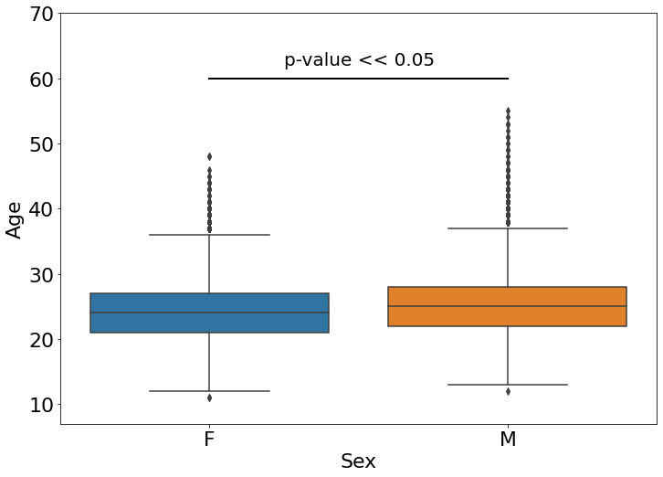

```python
age_fig = sns.boxplot(x=winter_subset['Sex'], y=winter_subset['Age'])
plt.axhline(60, linewidth=2, color='black', xmin=0.25, xmax=0.75)
plt.ylim(7, 70)
plt.text(0.25, 62, "p-value << 0.05", fontsize=20, color='black');
```

```python
#age_fig.figure.savefig("age.png")
```

```python
ttest_ind(winter_f_subset['Height'], winter_m_subset['Height'])
```

```
Ttest_indResult(statistic=-179.06226056048396, pvalue=0.0)
```

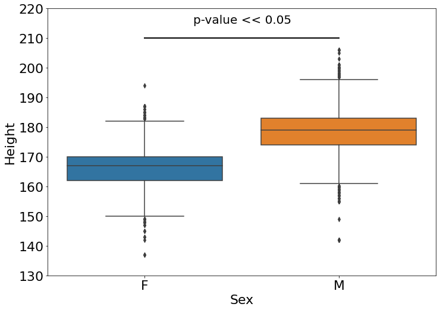

```python
height_fig = sns.boxplot(x=winter_subset['Sex'], y=winter_subset['Height'])
plt.axhline(210, linewidth=2, color='black', xmin=0.25, xmax=0.75)
plt.ylim(130, 220)
plt.text(0.25, 215, "p-value << 0.05", fontsize=20, color='black');
```

```python
#height_fig.figure.savefig("height.png")
```

```python
ttest_ind(winter_f_subset['Weight'], winter_m_subset['Weight'], equal_var=False)
```

```
Ttest_indResult(statistic=-188.05451036561354, pvalue=0.0)
```

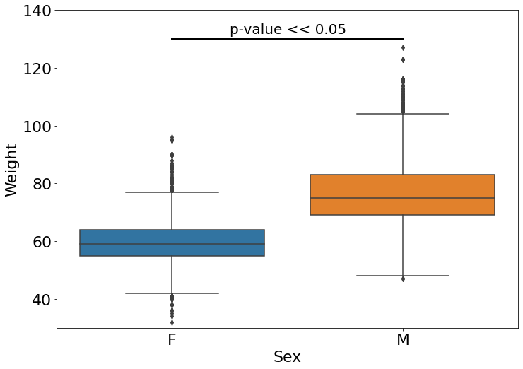

```python
weight_fig = sns.boxplot(x=winter_subset['Sex'], y=winter_subset['Weight'])
plt.axhline(130, linewidth=2, color='black', xmin=0.25, xmax=0.75)
plt.ylim(30, 140)
plt.text(0.25, 132, "p-value << 0.05", fontsize=20, color='black');
```

```python
#weight_fig.figure.savefig("weight.png")
```

Men were older, taller and heavier.

## 15. Team and medal

Well, of course they are connected, because different teams have different number of medals...

```python
gold_madals = athlete_events.query("Medal == 'Gold'")
```

```python
gold_madals = gold_madals.groupby('Team').agg({'Medal': 'value_counts'})
```

```python
gold_madals = gold_madals.rename(columns={'Medal':'Gold_medals'})
```

```python
gold_madals = gold_madals.reset_index().drop('Medal', axis=1)
```

```python
gold_madals
```

|  | Team | Gold_medals |
| --- | --- | --- |
| 0 | Algeria | 5 |
| 1 | Amateur Athletic Association | 2 |
| 2 | Argentina | 72 |
| 3 | Armenia | 2 |
| 4 | Australia | 313 |
| ... | ... | ... |
| 152 | West Germany-2 | 2 |
| 153 | White Lady | 3 |
| 154 | Winnipeg Shamrocks-1 | 2 |
| 155 | Yugoslavia | 122 |
| 156 | Zimbabwe | 17 |

157 rows × 2 columns

```python
all_medals = subset_medals.groupby('Team').agg({'Medal': 'count'})
```

```python
all_medals = all_medals.reset_index().rename(columns={'Medal':'Total_medals'})
```

```python
all_medals
```

|  | Team | Total_medals |
| --- | --- | --- |
| 0 | Afghanistan | 2 |
| 1 | Algeria | 15 |
| 2 | Amateur Athletic Association | 2 |
| 3 | Aphrodite | 3 |
| 4 | Argentina | 216 |
| ... | ... | ... |
| 258 | Widgeon | 2 |
| 259 | Winnipeg Shamrocks-1 | 2 |
| 260 | Yugoslavia | 321 |
| 261 | Zambia | 1 |
| 262 | Zimbabwe | 22 |

263 rows × 2 columns

```python
merged_medals = all_medals.merge(gold_madals, how='outer').fillna(0)
```

```python
merged_medals['Gold_medals'] = merged_medals['Gold_medals'].astype('int64')
```

```python
merged_medals
```

|  | Team | Total_medals | Gold_medals |
| --- | --- | --- | --- |
| 0 | Afghanistan | 2 | 0 |
| 1 | Algeria | 15 | 5 |
| 2 | Amateur Athletic Association | 2 | 2 |
| 3 | Aphrodite | 3 | 0 |
| 4 | Argentina | 216 | 72 |
| ... | ... | ... | ... |
| 258 | Widgeon | 2 | 0 |
| 259 | Winnipeg Shamrocks-1 | 2 | 2 |
| 260 | Yugoslavia | 321 | 122 |
| 261 | Zambia | 1 | 0 |
| 262 | Zimbabwe | 22 | 17 |

263 rows × 3 columns

```python
sorted_medals = merged_medals.sort_values('Total_medals', ascending=False)
```

```python
sorted_medals
```

|  | Team | Total_medals | Gold_medals |
| --- | --- | --- | --- |
| 243 | United States | 4273 | 2075 |
| 205 | Soviet Union | 2203 | 961 |
| 83 | Germany | 1518 | 508 |
| 8 | Australia | 1196 | 313 |
| 184 | Russia | 1091 | 356 |
| ... | ... | ... | ... |
| 180 | Rose Pompon | 1 | 0 |
| 95 | Haiti | 1 | 0 |
| 94 | Guyana | 1 | 0 |
| 93 | Guatemala | 1 | 0 |
| 131 | London City Police-1 | 1 | 1 |

263 rows × 3 columns

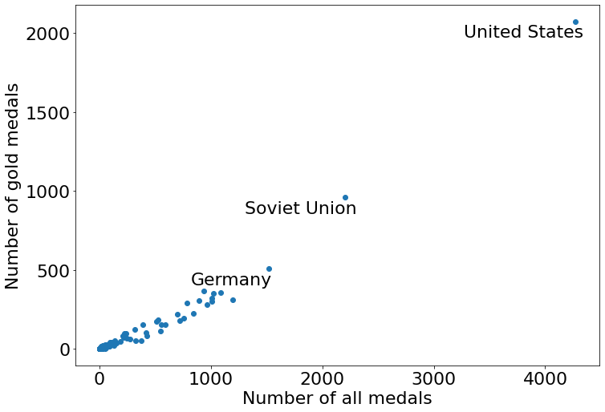

```python
plt.scatter(merged_medals['Total_medals'], merged_medals['Gold_medals'])
plt.xlabel("Number of all medals")
plt.ylabel("Number of gold medals")

plt.text(sorted_medals.iloc[0, 1] - 1000, sorted_medals.iloc[0, 2] - 100, sorted_medals.iloc[0, 0])
plt.text(sorted_medals.iloc[1, 1] - 900, sorted_medals.iloc[1, 2] - 100, sorted_medals.iloc[1, 0])
plt.text(sorted_medals.iloc[2, 1] - 700, sorted_medals.iloc[2, 2] - 100, sorted_medals.iloc[2, 0])
```

## 16. Some hypotheses

### Difference in height in two different sports

```python
athlete_events['Sport'].unique()
```

```
array(['Rugby Sevens', 'Biathlon', 'Athletics', 'Softball', 'Cycling',
       'Cross Country Skiing', 'Equestrianism', 'Snowboarding',
       'Alpine Skiing', 'Shooting', 'Canoeing', 'Handball', 'Boxing',
       'Bobsleigh', 'Modern Pentathlon', 'Hockey', 'Gymnastics', 'Tennis',
       'Swimming', 'Baseball', 'Fencing', 'Sailing', 'Football', 'Diving',
       'Rowing', 'Badminton', 'Ice Hockey', 'Freestyle Skiing',
       'Figure Skating', 'Speed Skating', 'Weightlifting', 'Wrestling',
       'Archery', 'Judo', 'Golf', 'Nordic Combined', 'Water Polo',
       'Triathlon', 'Basketball', 'Beach Volleyball',
       'Rhythmic Gymnastics', 'Volleyball', 'Taekwondo',
       'Short Track Speed Skating', 'Table Tennis',
       'Synchronized Swimming', 'Skeleton', 'Ski Jumping', 'Luge',
       'Trampolining', 'Tug-Of-War', 'Curling', 'Rugby', 'Lacrosse',
       'Art Competitions', 'Motorboating'], dtype=object)
```

H0: there is no difference in height of sportsmen in Judo and Basketball.

H1: Height of sportsmen in Judo and Basketball is different.

```python
judo_bas_m = athlete_events.query('Sport == "Judo" or Sport == "Basketball"').query('Sex == "M"')
```

```python
judo_height = judo_bas_m.query('Sport == "Judo"')['Height']
judo_height.var()
```

```
88.91045336440325
```

```python
basketball_height = judo_bas_m.query('Sport == "Basketball"')['Height']
basketball_height.var()
```

```
102.53465343917908
```

```python
ttest_ind(judo_height, basketball_height)
```

```
Ttest_indResult(statistic=-63.83963796119676, pvalue=0.0)
```

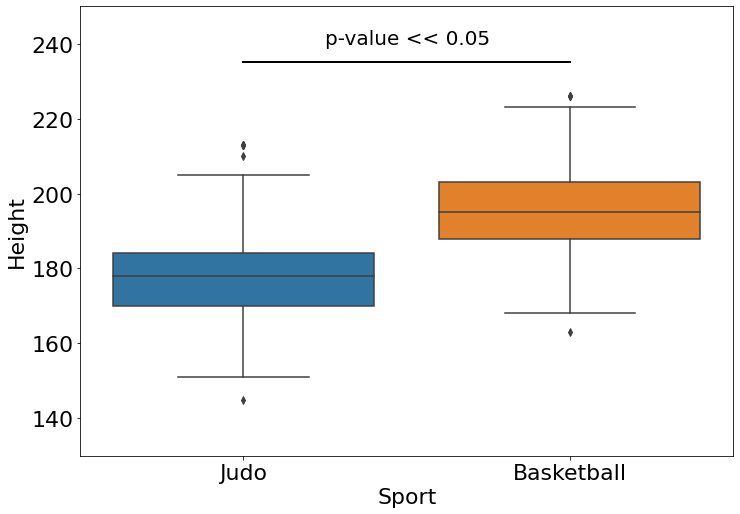

```python
sns.boxplot(data=judo_bas_m, x="Sport", y="Height")
plt.axhline(235, linewidth=2, color='black', xmin=0.25, xmax=0.75)
plt.ylim(130, 250)
plt.text(0.25, 240, "p-value << 0.05", fontsize=20, color='black');
```

Basketball players are higher.

### Weight in two differnt sports

H0: There is no difference in weight of sportsmen in Judo and Boxing.

H1: Weight of sportsmen in Judo and Boxing is different.

```python
judo_box_m = athlete_events.query('Sport == "Judo" or Sport == "Boxing"').query('Sex == "M"')
```

```python
judo_weight = judo_box_m.query('Sport == "Judo"')['Weight']
judo_weight.var()
```

```
416.50892038421364
```

```python
boxing_weight = judo_box_m.query('Sport == "Boxing"')['Weight']
boxing_weight.var()
```

```
172.50326040145046
```

```python
ttest_ind(judo_weight, boxing_weight, equal_var=False)
```

```
Ttest_indResult(statistic=39.598017632487085, pvalue=2.625437466799455e-283)
```

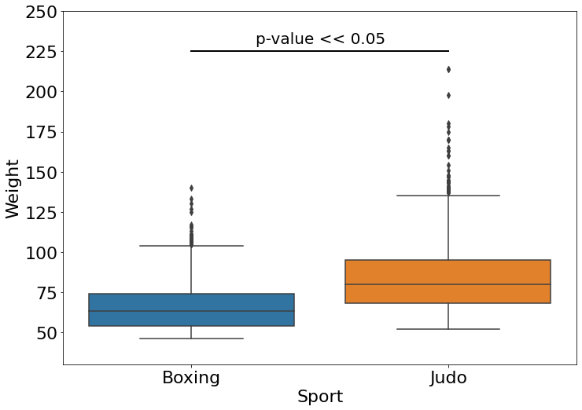

```python
sns.boxplot(data=judo_box_m, x="Sport", y="Weight")
plt.axhline(225, linewidth=2, color='black', xmin=0.25, xmax=0.75)
plt.ylim(30, 250)
plt.text(0.25, 230, "p-value << 0.05", fontsize=20, color='black');
```

Judo sportsmen are heavier (I thought the opposite...)

### How number of women and men changed

Let's check to intervals: in 20th century and in 21st.

```python
athlete_events_21 = athlete_events.query("2000 < Year <= 2010")
```

```python
athlete_events_20 = athlete_events.query("1950 < Year <= 1960")
```

```python
athlete_events_21['Sex'].value_counts()
```

```
M    23183
F    16420
Name: Sex, dtype: int64
```

```python
athlete_events_20['Sex'].value_counts()
```

```
M    10231
F     2459
Name: Sex, dtype: int64
```

```python
m_20 = athlete_events_20["Sex"].value_counts()['M']
f_20 = athlete_events_20["Sex"].value_counts()['F']
total_20 = athlete_events_20.shape[0]

m_21 = athlete_events_21["Sex"].value_counts()['M']
f_21 = athlete_events_21["Sex"].value_counts()['F']
total_21 = athlete_events_21.shape[0]
```

```python
f_part = (f_20 +  f_21) / (total_20 + total_21)
m_part = (m_20 +  m_21) / (total_20 + total_21)
```

```python
m_20_exp = total_20 * m_part
f_20_exp = total_20 * f_part
m_21_exp = total_21 * m_part
f_21_exp = total_21 * f_part
```

```python
chisquare([m_20, f_20, m_21, f_21], f_exp=[m_20_exp, f_20_exp, m_21_exp, f_21_exp])
```

```
Power_divergenceResult(statistic=2031.8094406057648, pvalue=0.0)
```

Looks like the ratio of men and women really changed.

```python
year_count = athlete_events.groupby('Year').agg({'Sex': 'value_counts'})
year_count = year_count.rename(columns={'Sex':'Count'}).reset_index()
```

```python
year_count.head()
```

|  | Year | Sex | Count |
| --- | --- | --- | --- |
| 0 | 1896 | M | 40 |
| 1 | 1900 | M | 71 |
| 2 | 1904 | M | 119 |
| 3 | 1906 | M | 201 |
| 4 | 1908 | M | 365 |

```python
year_total = year_count.groupby('Year').agg({'Count': 'sum'}).reset_index()
```

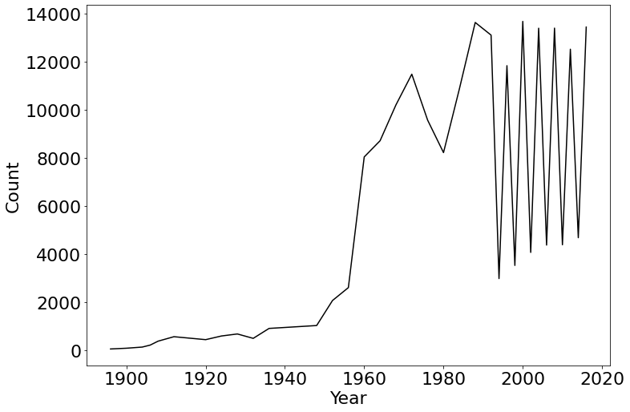

```python
sns.lineplot(data=year_total, x="Year", y="Count", color='black')
```

This is how number of all participants changed: it became sharply bigger in 1950s. I suppose that fluctuations in the end reflect the division to winter and summer games to different years.

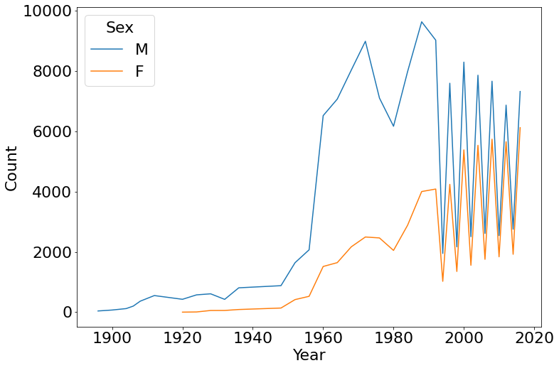

```python
sns.lineplot(data=year_count, x="Year", y="Count", hue="Sex")
```

We can see, that number of men doesn't considerably change since 1960s, but number of women is slightly growing.